# Lab 1. Introduction and Contingency Tables

Discrete Data Analysis and Lab. (326.314)

Author

Junseok Lee

Published

September 19, 2026

## 1. Introduction

### Statistical Distributions

R provides four standard functions for most probability distributions. The prefix `d` gives a probability mass or density, `p` gives a cumulative probability, `q` gives a quantile, and `r` generates random values. For a discrete distribution, a `d` function returns a probability mass. Setting `lower.tail = FALSE` in a `p` function returns a right-tail probability.

| Distribution | Function name | Additional arguments |
| --- | --- | --- |
| Binomial | `binom` | `size`, `prob` |
| Beta | `beta` | `shape1`, `shape2`, `ncp` |
| Chi-squared | `chisq` | `df`, `ncp` |
| Normal | `norm` | `mean`, `sd` |
| $t$ | `t` | `df`, `ncp` |
| $F$ | `f` | `df1`, `df2`, `ncp` |
| Poisson | `pois` | `lambda` |
| Uniform | `unif` | `min`, `max` |

```r
2 * pnorm(-1.96)
```

```
[1] 0.04999579
```

```r
pchisq(1.96^2, df = 1)
```

```
[1] 0.9500042
```

```r
pchisq(1.96^2, df = 1, lower.tail = FALSE)
```

```
[1] 0.04999579
```

```r
qchisq(0.95, df = 1)
```

```
[1] 3.841459
```

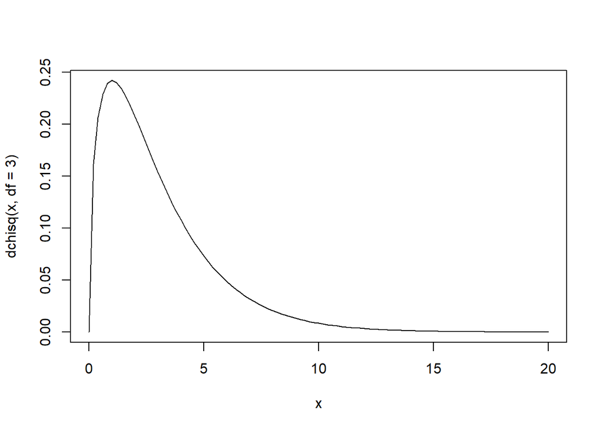

```r
curve(dchisq(x, df = 3), from = 0, to = 20)
```

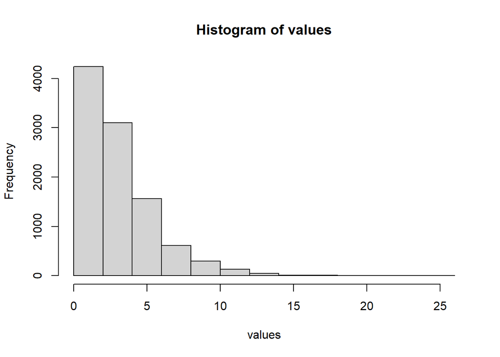

```r
set.seed(20230919)
values <- rchisq(10000, df = 3)
hist(values)
```

### Basic Asymptotic Properties

The following large-sample properties are fundamental for statistical inference.

#### Law of Large Numbers

Suppose $X_1,\ldots,X_n$ are independent and identically distributed with $E(X_i)=\mu$ and $\operatorname{Var}(X_i)=\sigma^2<\infty$. Then

$$\bar X=\frac{1}{n}\sum_{i=1}^n X_i \xrightarrow{p} \mu.$$

For Bernoulli observations, this result states that the sample proportion approaches the population proportion as the sample size increases.

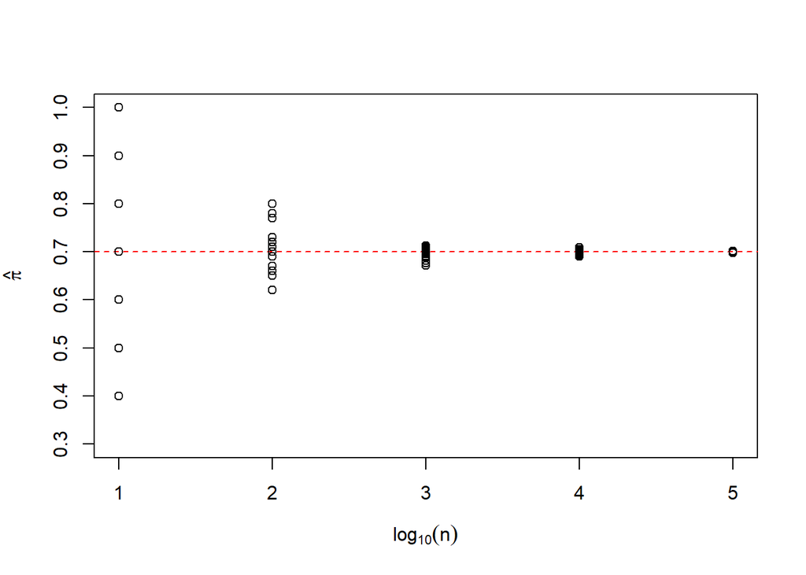

```r
p <- 0.7
sample_sizes <- 10^(1:5)
phat <- sapply(sample_sizes, function(n) mean(rbinom(n, size = 1, prob = p)))

plot(
  log10(sample_sizes), phat,
  ylim = c(0.3, 1),
  xlab = expression(log[10](n)),
  ylab = expression(hat(pi))
)
abline(h = p, lty = 2, col = "red")

for (j in 1:20) {
  phat <- sapply(sample_sizes, function(n) mean(rbinom(n, size = 1, prob = p)))
  points(log10(sample_sizes), phat)
}
```

#### Central Limit Theorem

Under the same conditions,

$$\frac{\sqrt{n}(\bar X-\mu)}{\sigma}\xrightarrow{d}N(0,1).$$

In particular, if $Y\sim\operatorname{Bin}(n,p)$, its distribution can be approximated by $N\{np,np(1-p)\}$ when both $np$ and $n(1-p)$ are sufficiently large.

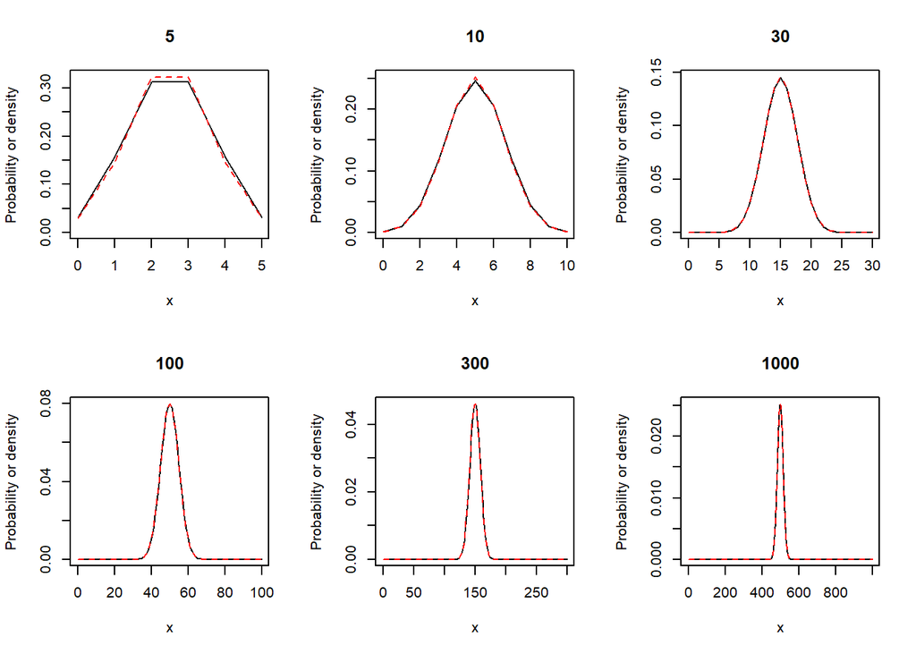

```r
p <- 0.5
sample_sizes <- c(5, 10, 30, 100, 300, 1000)
x_values <- lapply(sample_sizes, function(n) 0:n)

par(mfrow = c(2, 3))
for (i in seq_along(sample_sizes)) {
  n <- sample_sizes[i]
  x <- x_values[[i]]
  mu <- n * p
  sd <- sqrt(n * p * (1 - p))
  binomial_mass <- dbinom(x, size = n, prob = p)
  normal_density <- dnorm(x, mean = mu, sd = sd)
  plot(
    x, binomial_mass,
    type = "l",
    main = n,
    xlab = "x",
    ylab = "Probability or density",
    ylim = c(0, max(binomial_mass, normal_density))
  )
  lines(x, normal_density, col = "red", lty = 2)
}
```

```r
par(mfrow = c(1, 1))
```

When $p$ is close to 0 or 1, a larger sample size is needed for a satisfactory normal approximation.

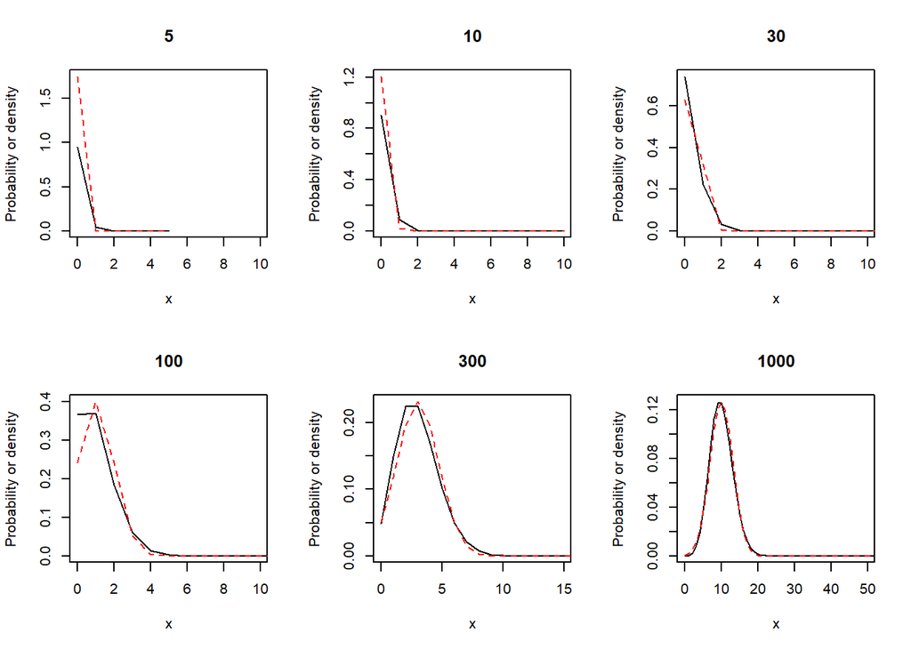

```r
p <- 0.01
sample_sizes <- c(5, 10, 30, 100, 300, 1000)
x_values <- lapply(sample_sizes, function(n) 0:n)

par(mfrow = c(2, 3))
for (i in seq_along(sample_sizes)) {
  n <- sample_sizes[i]
  x <- x_values[[i]]
  mu <- n * p
  sd <- sqrt(n * p * (1 - p))
  binomial_mass <- dbinom(x, size = n, prob = p)
  normal_density <- dnorm(x, mean = mu, sd = sd)
  plot(
    x, binomial_mass,
    type = "l",
    main = n,
    xlab = "x",
    ylab = "Probability or density",
    xlim = c(0, max(10, 5 * mu)),
    ylim = c(0, max(binomial_mass, normal_density))
  )
  lines(x, normal_density, col = "red", lty = 2)
}
```

```r
par(mfrow = c(1, 1))
```

### Statistical Inference for a Proportion

For $Y\sim\operatorname{Bin}(n,\pi)$, the maximum likelihood estimate is $\hat\pi=Y/n$. The Wald method uses an estimated standard error evaluated at $\hat\pi$. It can perform poorly for small samples or when the sample proportion is close to 0 or 1. Score inference evaluates the standard error under the null and is generally more reliable in those settings.

The function `prop.test()` tests whether one or more proportions equal specified values or whether several proportions are equal.

```
prop.test(x, n, p = NULL, alternative = c("two.sided", "less", "greater"),
          conf.level = 0.95, correct = TRUE)
```

| Argument | Description |
| --- | --- |
| `x` | Count or vector of counts of successes |
| `n` | Number or vector of numbers of trials |
| `p` | Null probability or vector of null probabilities |
| `conf.level` | Confidence level |
| `correct` | Whether to apply a continuity correction |

#### Example: Surveyed Opinions about Legalized Abortion

For $n=1810$, 837 respondents answered yes and 973 answered no.

$$H_0:\pi=0.5 \quad\text{versus}\quad H_a:\pi\ne0.5.$$

```r
prop.test(837, 1810, p = 0.5, alternative = "two.sided", correct = FALSE)
```

```
    1-sample proportions test without continuity correction

data:  837 out of 1810, null probability 0.5
X-squared = 10.219, df = 1, p-value = 0.00139
alternative hypothesis: true p is not equal to 0.5
95 percent confidence interval:
 0.4395653 0.4854557
sample estimates:
        p
0.4624309
```

$$H_0:\pi=0.5 \quad\text{versus}\quad H_a:\pi<0.5.$$

```r
prop.test(837, 1810, p = 0.5, alternative = "less", correct = FALSE)
```

```
    1-sample proportions test without continuity correction

data:  837 out of 1810, null probability 0.5
X-squared = 10.219, df = 1, p-value = 0.0006951
alternative hypothesis: true p is less than 0.5
95 percent confidence interval:
 0.0000000 0.4817492
sample estimates:
        p
0.4624309
```

The function `read.table()` imports rectangular data. Common separators are `""` for white space, `"\t"` for tabs, and `","` for commas.

```r
Clinical <- read.table(
  "https://raw.githubusercontent.com/alanagresti/categorical-data/master/Clinical.dat",
  header = TRUE
)
Clinical
```

| subject | response |
| --- | --- |
| 1 | 1 |
| 2 | 1 |
| 3 | 1 |
| 4 | 1 |
| 5 | 1 |
| 6 | 1 |
| 7 | 1 |
| 8 | 1 |
| 9 | 1 |
| 10 | 0 |

The score confidence interval for the probability of success in the clinical data is

```r
y <- sum(Clinical$response)
prop.test(y, nrow(Clinical), conf.level = 0.95, correct = FALSE)$conf.int
```

```
[1] 0.5958500 0.9821238
attr(,"conf.level")
[1] 0.95
```

The function `binom.confint()` provides several confidence intervals for a binomial probability.

```r
library(binom)

binom.confint(9, 10, conf.level = 0.95, methods = "asymptotic")
```

|  | method | x | n | mean | lower | upper |
| --- | --- | --- | --- | --- | --- | --- |
| 1 | asymptotic | 9 | 10 | 0.9 | 0.7140615 | 1.085939 |

```r
binom.confint(9, 10, conf.level = 0.95, methods = "wilson")
```

|  | method | x | n | mean | lower | upper |
| --- | --- | --- | --- | --- | --- | --- |
| 1 | wilson | 9 | 10 | 0.9 | 0.59585 | 0.9821238 |

```r
binom.confint(9, 10, conf.level = 0.95, methods = "ac")
```

|  | method | x | n | mean | lower | upper |
| --- | --- | --- | --- | --- | --- | --- |
| 1 | agresti-coull | 9 | 10 | 0.9 | 0.5740323 | 1.003941 |

#### Mid-$P$ Value

Exact inference for a discrete distribution can be conservative because the actual type I error probability may be smaller than the nominal significance level. A mid-$P$ value adds half the probability of the observed outcome to the probability of more extreme outcomes. It reduces conservativeness, but the use of the mid-$P$ definition should be stated when results are reported.

```r
library(exactci)
binom.exact(9, 10, p = 0.5, alternative = "greater", midp = TRUE)$p.value
```

```
[1] 0.005859375
```

```r
choose(10, 9) * 0.5^10 / 2 + choose(10, 10) * 0.5^10
```

```
[1] 0.005859375
```

```r
library(PropCIs)

midPci(9, 10, conf.level = 0.95)
```

```
data:

95 percent confidence interval:
 0.5966 0.9946
```

## 2. Contingency Tables

### Difference of Proportions

For two independent binomial samples with sample sizes $n_1$ and $n_2$, the estimated standard error of $\hat\pi_1-\hat\pi_2$ is

$$SE=\sqrt{\frac{\hat\pi_1(1-\hat\pi_1)}{n_1}+
\frac{\hat\pi_2(1-\hat\pi_2)}{n_2}}.$$

A Wald $100(1-\alpha)\%$ confidence interval for $\pi_1-\pi_2$ is

$$(\hat\pi_1-\hat\pi_2)\mathbin{\pm}z_{\alpha/2}SE.$$

Three common measures for comparing two success probabilities are

- risk difference: $\pi_1-\pi_2$;
- relative risk: $\pi_1/\pi_2$;
- odds ratio: $\{\pi_1/(1-\pi_1)\}/\{\pi_2/(1-\pi_2)\}$.

Their null values are 0, 1, and 1, respectively. When both probabilities are close to zero, the relative risk and odds ratio have similar values.

For a $2\times2$ table, the estimated standard error of the sample log odds ratio is

$$SE\{\log(\widehat{OR})\}
=\sqrt{\frac{1}{n_{11}}+\frac{1}{n_{12}}+\frac{1}{n_{21}}+\frac{1}{n_{22}}}.$$

A Wald confidence interval is first constructed for $\log(OR)$ and then exponentiated to obtain an interval for $OR$.

#### Example: Aspirin Use and Myocardial Infarction

| Group | Myocardial infarction: Yes | Myocardial infarction: No | Total |
| --- | --- | --- | --- |
| Placebo | 189 | 10,845 | 11,034 |
| Aspirin | 104 | 10,933 | 11,037 |
| Total | 293 | 21,778 | 22,071 |

Both event proportions are close to 1%, so the sample relative risk and odds ratio are nearly equal.

```r
p1 <- 189 / 11034
p2 <- 104 / 11037
se_difference <- sqrt(p1 * (1 - p1) / 11034 + p2 * (1 - p2) / 11037)

p1 - p2
```

```
[1] 0.007706024
```

```r
c(
  lower = p1 - p2 - qnorm(0.975) * se_difference,
  upper = p1 - p2 + qnorm(0.975) * se_difference
)
```

```
      lower       upper
0.004687751 0.010724297
```

```r
prop.test(
  c(189, 104),
  c(11034, 11037),
  conf.level = 0.95,
  correct = FALSE
)
```

```
    2-sample test for equality of proportions without continuity correction

data:  c(189, 104) out of c(11034, 11037)
X-squared = 25.014, df = 1, p-value = 5.692e-07
alternative hypothesis: two.sided
95 percent confidence interval:
 0.004687751 0.010724297
sample estimates:
    prop 1     prop 2
0.01712887 0.00942285
```

```r
library(PropCIs)

diffscoreci(189, 11034, 104, 11037, conf.level = 0.95)
```

```
data:

95 percent confidence interval:
 0.004716821 0.010788501
```

```r
orscoreci(189, 11034, 104, 11037, conf.level = 0.95)
```

```
data:

95 percent confidence interval:
 1.440802 2.329551
```